# HW1

### Part 2

**We see some odd outliers here. Plot the country names. Which nations are the outliers?**

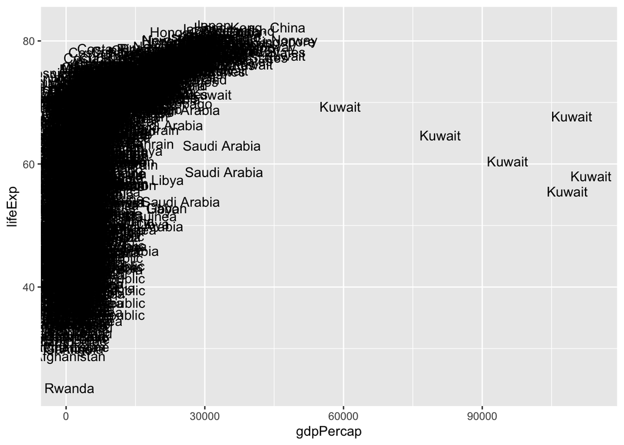

```r
ggplot(gapminder) +
  geom_text(aes(x=gdpPercap,y=lifeExp, label = country))
```

The clear outlier is Kuwait. I would conclude that Kuwait’s GDP per capita varied significantly, in comparison to other countries, after WW2. Also, I would say that Kuwait has had GDP per capita values greater that other countries.

### Part 3

**Building on your original plot, show each continent in a separate color, and also add a smoother for each continent.**

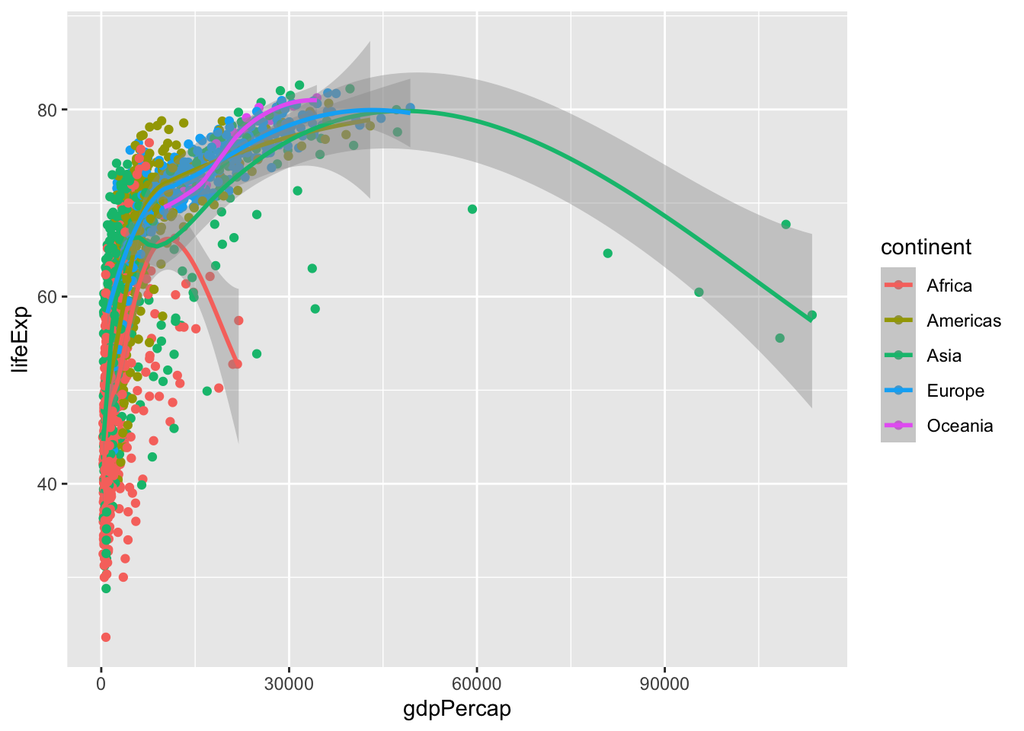

```r
ggplot(gapminder, aes(x=gdpPercap,y=lifeExp, color = continent)) +
  geom_point() +
  geom_smooth()
```

From the plot, Asia has a trend on the relationship between GDP per capita and Life Expectancy that extends beyond that of others, as we have seen this is due to Kuwait being an outlier. This trend also happens to reach a maximum Life Expectancy point around the 45000 GDP per capita mark and then go down the higher the GDP is. This is surprising because one would expect the Life Expectancy to be high the higher the GDP per capita, yet this suggests otherwise, at least in Asia.

Other continents, the Americas, Europe and Oceania, have a moderate trend where there are no significant outliers and the trends go up suggesting a positive relationship between GDP per capita and Life Expectancy.

However, African countries show to not surpass the 30000 GDP per capita mark, with a smoother that begins going up and then falls back down.